# INN_Learner_Notebook_Full_code (1)

Bank Churn Prediction

## Problem Statement

### Context

Businesses like banks which provide service have to worry about problem of 'Customer Churn' i.e. customers leaving and joining another service provider. It is important to understand which aspects of the service influence a customer's decision in this regard. Management can concentrate efforts on improvement of service, keeping in mind these priorities.

### Objective

You as a Data scientist with the bank need to build a neural network based classifier that can determine whether a customer will leave the bank or not in the next 6 months.

### Data Dictionary

- CustomerId: Unique ID which is assigned to each customer
- Surname: Last name of the customer
- CreditScore: It defines the credit history of the customer.
- Geography: A customer’s location
- Gender: It defines the Gender of the customer
- Age: Age of the customer
- Tenure: Number of years for which the customer has been with the bank
- NumOfProducts: refers to the number of products that a customer has purchased through the bank.
- Balance: Account balance
- HasCrCard: It is a categorical variable which decides whether the customer has credit card or not.
- EstimatedSalary: Estimated salary
- isActiveMember: Is is a categorical variable which decides whether the customer is active member of the bank or not ( Active member in the sense, using bank products regularly, making transactions etc )
- Exited : whether or not the customer left the bank within six month. It can take two values

** 0=No ( Customer did not leave the bank ) ** 1=Yes ( Customer left the bank )

## Importing necessary libraries

```python
!pip install tensorflow==2.15.0 scikit-learn==1.2.2 matplotlib===3.7.1 seaborn==0.13.1 numpy==1.25.2 pandas==1.5.3 -q --user
```

[output not shown]

```python
# Library for data manipulation and analysis.
import pandas as pd
# Fundamental package for scientific computing.
import numpy as np
#splitting datasets into training and testing sets.
from sklearn.model_selection import train_test_split
#Imports tools for data preprocessing including label encoding, one-hot encoding, and standard scaling
from sklearn.preprocessing import LabelEncoder, OneHotEncoder,StandardScaler
#Imports a class for imputing missing values in datasets.
from sklearn.impute import SimpleImputer
#Imports the Matplotlib library for creating visualizations.
import matplotlib.pyplot as plt
# Imports the Seaborn library for statistical data visualization.
import seaborn as sns
# Time related functions.
import time
#Imports functions for evaluating the performance of machine learning models
from sklearn.metrics import confusion_matrix, f1_score,accuracy_score, recall_score, precision_score, classification_report


#Imports the tensorflow,keras and layers.
import tensorflow
import tensorflow as tf
from tensorflow.keras.models import Sequential
from tensorflow.keras.layers import Dense
from tensorflow.keras.layers import Dense, Input, Dropout,BatchNormalization
from tensorflow.keras import backend

# to suppress unnecessary warnings
import warnings
warnings.filterwarnings("ignore")
```

```python
# Set the seed using keras.utils.set_random_seed. This will set:
# 1) `numpy` seed
# 2) backend random seed
# 3) `python` random seed
tf.keras.utils.set_random_seed(812)

# If using TensorFlow, this will make GPU ops as deterministic as possible,
# but it will affect the overall performance, so be mindful of that.
tf.config.experimental.enable_op_determinism()
```

## Loading the dataset

```python
Data = pd.read_csv('bank-1.csv')
```

## Data Overview

```python
Data.head()
```

|  | RowNumber | CustomerId | Surname | CreditScore | Geography | Gender | Age | Tenure | Balance | NumOfProducts | HasCrCard | IsActiveMember | EstimatedSalary | Exited |
| --- | --- | --- | --- | --- | --- | --- | --- | --- | --- | --- | --- | --- | --- | --- |
| 0 | 1 | 15634602 | Hargrave | 619 | France | Female | 42 | 2 | 0.00 | 1 | 1 | 1 | 101348.88 | 1 |
| 1 | 2 | 15647311 | Hill | 608 | Spain | Female | 41 | 1 | 83807.86 | 1 | 0 | 1 | 112542.58 | 0 |
| 2 | 3 | 15619304 | Onio | 502 | France | Female | 42 | 8 | 159660.80 | 3 | 1 | 0 | 113931.57 | 1 |
| 3 | 4 | 15701354 | Boni | 699 | France | Female | 39 | 1 | 0.00 | 2 | 0 | 0 | 93826.63 | 0 |
| 4 | 5 | 15737888 | Mitchell | 850 | Spain | Female | 43 | 2 | 125510.82 | 1 | 1 | 1 | 79084.10 | 0 |

```python
Data.tail()
```

|  | RowNumber | CustomerId | Surname | CreditScore | Geography | Gender | Age | Tenure | Balance | NumOfProducts | HasCrCard | IsActiveMember | EstimatedSalary | Exited |
| --- | --- | --- | --- | --- | --- | --- | --- | --- | --- | --- | --- | --- | --- | --- |
| 9995 | 9996 | 15606229 | Obijiaku | 771 | France | Male | 39 | 5 | 0.00 | 2 | 1 | 0 | 96270.64 | 0 |
| 9996 | 9997 | 15569892 | Johnstone | 516 | France | Male | 35 | 10 | 57369.61 | 1 | 1 | 1 | 101699.77 | 0 |
| 9997 | 9998 | 15584532 | Liu | 709 | France | Female | 36 | 7 | 0.00 | 1 | 0 | 1 | 42085.58 | 1 |
| 9998 | 9999 | 15682355 | Sabbatini | 772 | Germany | Male | 42 | 3 | 75075.31 | 2 | 1 | 0 | 92888.52 | 1 |
| 9999 | 10000 | 15628319 | Walker | 792 | France | Female | 28 | 4 | 130142.79 | 1 | 1 | 0 | 38190.78 | 0 |

```python
Data.shape
```

```
(10000, 14)
```

```python
Data.info()
```

```
<class 'pandas.core.frame.DataFrame'>
RangeIndex: 10000 entries, 0 to 9999
Data columns (total 14 columns):
 #   Column           Non-Null Count  Dtype
---  ------           --------------  -----
 0   RowNumber        10000 non-null  int64
 1   CustomerId       10000 non-null  int64
 2   Surname          10000 non-null  object
 3   CreditScore      10000 non-null  int64
 4   Geography        10000 non-null  object
 5   Gender           10000 non-null  object
 6   Age              10000 non-null  int64
 7   Tenure           10000 non-null  int64
 8   Balance          10000 non-null  float64
 9   NumOfProducts    10000 non-null  int64
 10  HasCrCard        10000 non-null  int64
 11  IsActiveMember   10000 non-null  int64
 12  EstimatedSalary  10000 non-null  float64
 13  Exited           10000 non-null  int64
dtypes: float64(2), int64(9), object(3)
memory usage: 1.1+ MB
```

```python
Data.duplicated().sum()
```

```
np.int64(0)
```

```python
round(Data.isnull().sum() / Data.isnull().count() * 100, 2)
```

|  | 0 |
| --- | --- |
| RowNumber | 0.0 |
| CustomerId | 0.0 |
| Surname | 0.0 |
| CreditScore | 0.0 |
| Geography | 0.0 |
| Gender | 0.0 |
| Age | 0.0 |
| Tenure | 0.0 |
| Balance | 0.0 |
| NumOfProducts | 0.0 |
| HasCrCard | 0.0 |
| IsActiveMember | 0.0 |
| EstimatedSalary | 0.0 |
| Exited | 0.0 |

**dtype:** float64

```python
Data["Exited"].value_counts(1)
```

| Exited | proportion |
| --- | --- |
| 0 | 0.7963 |
| 1 | 0.2037 |

**dtype:** float64

```python
Data.describe().T
```

|  | count | mean | std | min | 25% | 50% | 75% | max |
| --- | --- | --- | --- | --- | --- | --- | --- | --- |
| RowNumber | 10000.0 | 5.000500e+03 | 2886.895680 | 1.00 | 2500.75 | 5.000500e+03 | 7.500250e+03 | 10000.00 |
| CustomerId | 10000.0 | 1.569094e+07 | 71936.186123 | 15565701.00 | 15628528.25 | 1.569074e+07 | 1.575323e+07 | 15815690.00 |
| CreditScore | 10000.0 | 6.505288e+02 | 96.653299 | 350.00 | 584.00 | 6.520000e+02 | 7.180000e+02 | 850.00 |
| Age | 10000.0 | 3.892180e+01 | 10.487806 | 18.00 | 32.00 | 3.700000e+01 | 4.400000e+01 | 92.00 |
| Tenure | 10000.0 | 5.012800e+00 | 2.892174 | 0.00 | 3.00 | 5.000000e+00 | 7.000000e+00 | 10.00 |
| Balance | 10000.0 | 7.648589e+04 | 62397.405202 | 0.00 | 0.00 | 9.719854e+04 | 1.276442e+05 | 250898.09 |
| NumOfProducts | 10000.0 | 1.530200e+00 | 0.581654 | 1.00 | 1.00 | 1.000000e+00 | 2.000000e+00 | 4.00 |
| HasCrCard | 10000.0 | 7.055000e-01 | 0.455840 | 0.00 | 0.00 | 1.000000e+00 | 1.000000e+00 | 1.00 |
| IsActiveMember | 10000.0 | 5.151000e-01 | 0.499797 | 0.00 | 0.00 | 1.000000e+00 | 1.000000e+00 | 1.00 |
| EstimatedSalary | 10000.0 | 1.000902e+05 | 57510.492818 | 11.58 | 51002.11 | 1.001939e+05 | 1.493882e+05 | 199992.48 |
| Exited | 10000.0 | 2.037000e-01 | 0.402769 | 0.00 | 0.00 | 0.000000e+00 | 0.000000e+00 | 1.00 |

Credit score ranges from 350 to 850, with an average of 650 and a median of 652. Standard deviation is high, at 97. Age ranges from 18 to 92, with an average of 39 and median of 37

```python
Data.nunique()
```

|  | 0 |
| --- | --- |
| RowNumber | 10000 |
| CustomerId | 10000 |
| Surname | 2932 |
| CreditScore | 460 |
| Geography | 3 |
| Gender | 2 |
| Age | 70 |
| Tenure | 11 |
| Balance | 6382 |
| NumOfProducts | 4 |
| HasCrCard | 2 |
| IsActiveMember | 2 |
| EstimatedSalary | 9999 |
| Exited | 2 |

**dtype:** int64

RowNumber CustomerId, and Surname can be dropped, as they are unique and will not be used in the model.

## Exploratory Data Analysis

```python
# Function to create labeled barplots


def labeled_barplot(data, feature, perc=False, n=None):
    """
    Barplot with percentage at the top

    data: dataframe
    feature: dataframe column
    perc: whether to display percentages instead of count (default is False)
    n: displays the top n category levels (default is None, i.e., display all levels)
    """

    total = len(data[feature])  # length of the column
    count = data[feature].nunique()
    if n is None:
        plt.figure(figsize=(count + 1, 5))
    else:
        plt.figure(figsize=(n + 1, 5))

    plt.xticks(rotation=90, fontsize=15)
    ax = sns.countplot(
        data=data,
        x=feature,
        palette="Paired",
        order=data[feature].value_counts().index[:n].sort_values(),
    )

    for p in ax.patches:
        if perc == True:
            label = "{:.1f}%".format(
                100 * p.get_height() / total
            )  # percentage of each class of the category
        else:
            label = p.get_height()  # count of each level of the category

        x = p.get_x() + p.get_width() / 2  # width of the plot
        y = p.get_height()  # height of the plot

        ax.annotate(
            label,
            (x, y),
            ha="center",
            va="center",
            size=12,
            xytext=(0, 5),
            textcoords="offset points",
        )  # annotate the percentage

    plt.show()  # show the plot
```

```python
# Function to plot a boxplot and a histogram along the same scale.


def histogram_boxplot(data, feature, figsize=(12, 7), kde=False, bins=None):
    """
    Boxplot and histogram combined

    data: dataframe
    feature: dataframe column
    figsize: size of figure (default (12,7))
    kde: whether to the show density curve (default False)
    bins: number of bins for histogram (default None)
    """
    f2, (ax_box2, ax_hist2) = plt.subplots(
        nrows=2,  # Number of rows of the subplot grid= 2
        sharex=True,  # x-axis will be shared among all subplots
        gridspec_kw={"height_ratios": (0.25, 0.75)},
        figsize=figsize,
    )  # creating the 2 subplots
    sns.boxplot(
        data=data, x=feature, ax=ax_box2, showmeans=True, color="violet"
    )  # boxplot will be created and a star will indicate the mean value of the column
    sns.histplot(
        data=data, x=feature, kde=kde, ax=ax_hist2, bins=bins, palette="winter"
    ) if bins else sns.histplot(
        data=data, x=feature, kde=kde, ax=ax_hist2
    )  # For histogram
    ax_hist2.axvline(
        data[feature].mean(), color="green", linestyle="--"
    )  # Add mean to the histogram
    ax_hist2.axvline(
        data[feature].median(), color="black", linestyle="-"
    )  # Add median to the histogram
```

```python
### Function to plot distributions


def distribution_plot_wrt_target(data, predictor, target):

    fig, axs = plt.subplots(2, 2, figsize=(12, 10))

    target_uniq = data[target].unique()

    axs[0, 0].set_title("Distribution of target for target=" + str(target_uniq[0]))
    sns.histplot(
        data=data[data[target] == target_uniq[0]],
        x=predictor,
        kde=True,
        ax=axs[0, 0],
        color="teal",
    )

    axs[0, 1].set_title("Distribution of target for target=" + str(target_uniq[1]))
    sns.histplot(
        data=data[data[target] == target_uniq[1]],
        x=predictor,
        kde=True,
        ax=axs[0, 1],
        color="orange",
    )

    axs[1, 0].set_title("Boxplot w.r.t target")
    sns.boxplot(data=data, x=target, y=predictor, ax=axs[1, 0], palette="gist_rainbow")

    axs[1, 1].set_title("Boxplot (without outliers) w.r.t target")
    sns.boxplot(
        data=data,
        x=target,
        y=predictor,
        ax=axs[1, 1],
        showfliers=False,
        palette="gist_rainbow",
    )

    plt.tight_layout()
    plt.show()
```

```python
# function to plot stacked bar chart


def stacked_barplot(data, predictor, target):
    """
    Print the category counts and plot a stacked bar chart

    data: dataframe
    predictor: independent variable
    target: target variable
    """
    count = data[predictor].nunique()
    sorter = data[target].value_counts().index[-1]
    tab1 = pd.crosstab(data[predictor], data[target], margins=True).sort_values(
        by=sorter, ascending=False
    )
    print(tab1)
    print("-" * 120)
    tab = pd.crosstab(data[predictor], data[target], normalize="index").sort_values(
        by=sorter, ascending=False
    )
    tab.plot(kind="bar", stacked=True, figsize=(count + 1, 5))
    plt.legend(
        loc="lower left",
        frameon=False,
    )
    plt.legend(loc="upper left", bbox_to_anchor=(1, 1))
    plt.show()
```

### Univariate Analysis

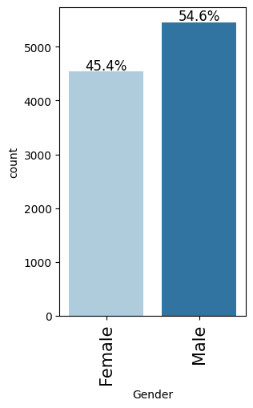

```python
labeled_barplot(Data, "Gender",perc=True)
```

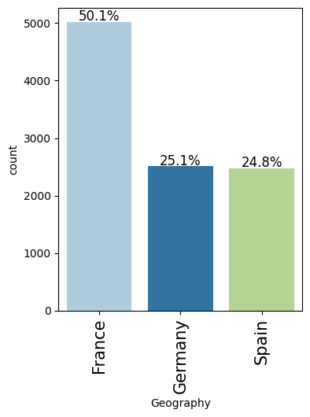

```python
labeled_barplot(Data, "Geography",perc=True)
```

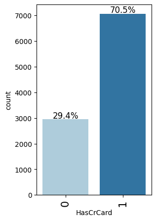

```python
labeled_barplot(Data, "HasCrCard",perc=True)
```

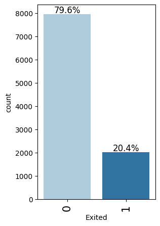

```python
labeled_barplot(Data, "Exited",perc=True)
```

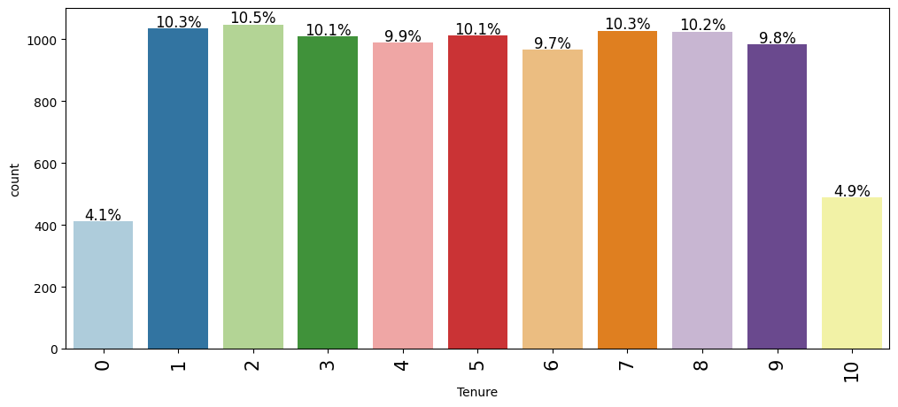

```python
labeled_barplot(Data, "Tenure",perc=True)
```

### Bivariate Analysis

```
Exited     0     1    All
Gender
All     7963  2037  10000
Female  3404  1139   4543
Male    4559   898   5457
------------------------------------------------------------------------------------------------------------------------
```

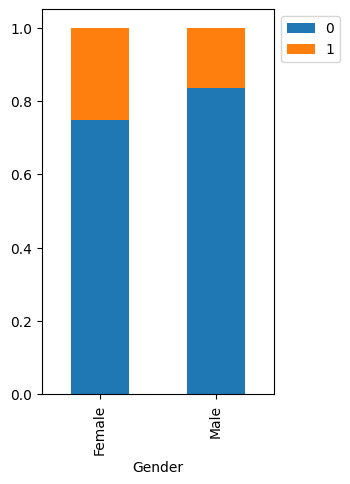

```python
stacked_barplot(Data, "Gender", "Exited")
```

```
Exited        0     1    All
Geography
All        7963  2037  10000
Germany    1695   814   2509
France     4204   810   5014
Spain      2064   413   2477
------------------------------------------------------------------------------------------------------------------------
```

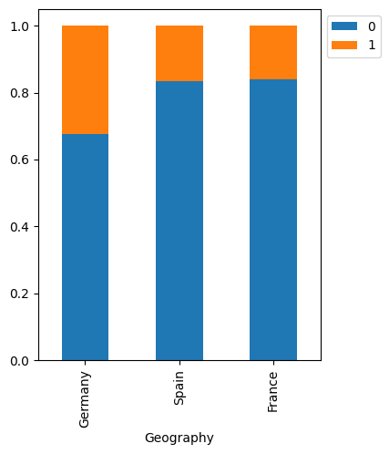

```python
stacked_barplot(Data, "Geography", "Exited")
```

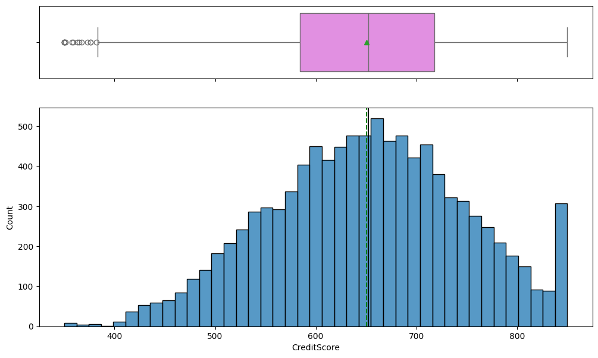

```python
histogram_boxplot(Data, "CreditScore")
```

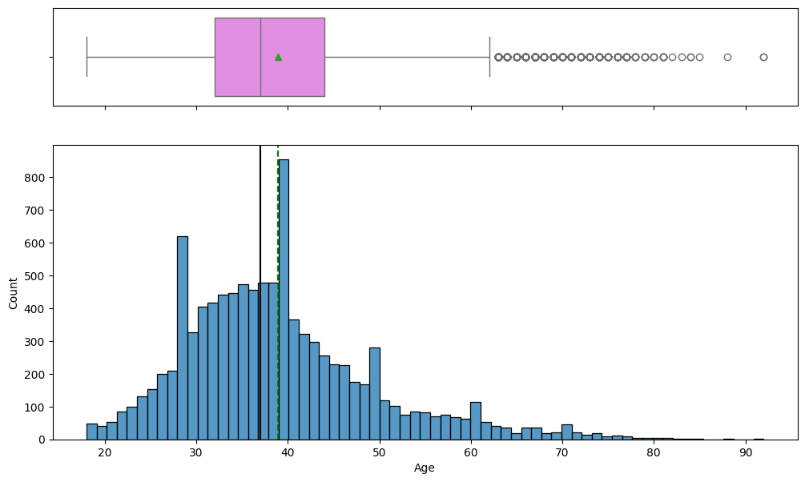

```python
histogram_boxplot(Data, "Age")
```

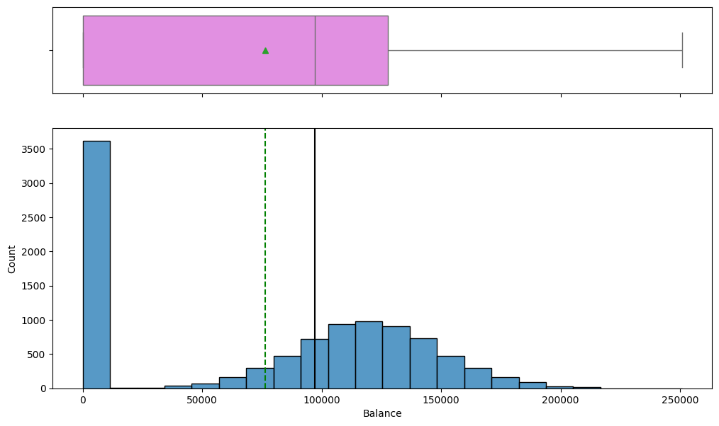

```python
histogram_boxplot(Data, "Balance")
```

```
Exited        0     1    All
HasCrCard
All        7963  2037  10000
1          5631  1424   7055
0          2332   613   2945
------------------------------------------------------------------------------------------------------------------------
```

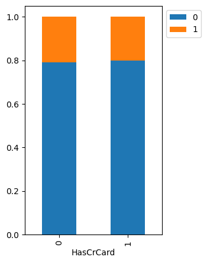

```python
stacked_barplot(Data, 'HasCrCard', 'Exited')
```

```
Exited             0     1    All
IsActiveMember
All             7963  2037  10000
0               3547  1302   4849
1               4416   735   5151
------------------------------------------------------------------------------------------------------------------------
```

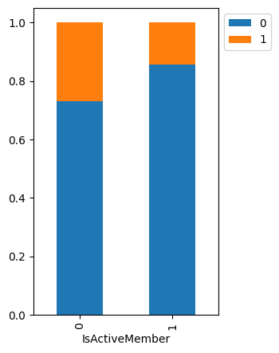

```python
stacked_barplot(Data, 'IsActiveMember', 'Exited')
```

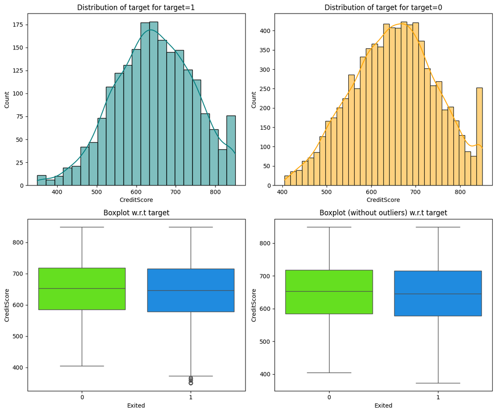

```python
distribution_plot_wrt_target(Data, "CreditScore", "Exited")
```

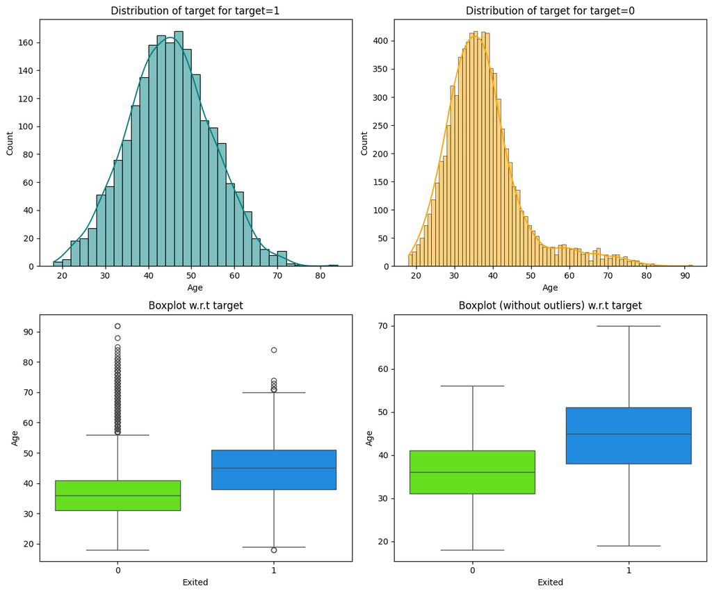

```python
distribution_plot_wrt_target(Data, "Age", "Exited")
```

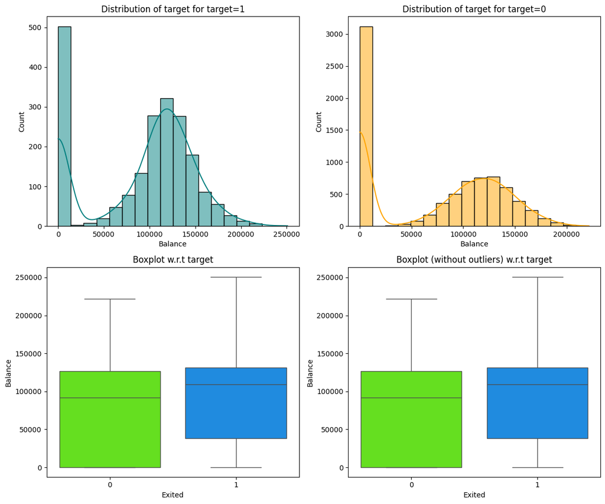

```python
distribution_plot_wrt_target(Data, "Balance", "Exited")
```

## Data Preprocessing

### Dummy Variable Creation

```python
X = Data.drop(['Exited', 'RowNumber', 'CustomerId', 'Surname'], axis=1)
Y = Data[['Exited']]
```

```python
X = pd.get_dummies(X, drop_first=True)
X = X.astype(float)
```

### Train-validation-test Split

```python
X_train, X_test, y_train, y_test = train_test_split(X,Y, test_size = 0.2, random_state = 42,stratify = Y)
```

```python
X_train, X_val, y_train, y_val = train_test_split(X_train,y_train, test_size = 0.2, random_state = 42,stratify = y_train)
```

```python
print(X_train.shape,y_train.shape)
print(X_val.shape,y_val.shape)
print(X_test.shape,y_test.shape)
```

```
(6400, 11) (6400, 1)
(1600, 11) (1600, 1)
(2000, 11) (2000, 1)
```

```python
print(type(y_train))
```

```
<class 'pandas.core.frame.DataFrame'>
```

### Data Normalization

```python
num_cols = ["CreditScore", "Age", "Tenure", "Balance", "EstimatedSalary"]


scaler = StandardScaler()
X_train[num_cols] = scaler.fit_transform(X_train[num_cols])


X_val[num_cols] = scaler.transform(X_val[num_cols])
X_test[num_cols] = scaler.transform(X_test[num_cols])
```

## Model Building

```python
def plot(history, name):
    """
    Function to plot loss/accuracy

    history: an object which stores the metrics and losses.
    name: can be one of Loss or Accuracy
    """
    fig, ax = plt.subplots() #Creating a subplot with figure and axes.
    plt.plot(history.history[name]) #Plotting the train accuracy or train loss
    plt.plot(history.history['val_'+name]) #Plotting the validation accuracy or validation loss

    plt.title('Model ' + name.capitalize()) #Defining the title of the plot.
    plt.ylabel(name.capitalize()) #Capitalizing the first letter.
    plt.xlabel('Epoch') #Defining the label for the x-axis.
    fig.legend(['Train', 'Validation'], loc="outside right upper") #Defining the legend, loc controls the position of the legend.
```

```python
# defining a function to compute different metrics to check performance of a classification model built using statsmodels
def model_performance_classification(
    model, predictors, target, threshold=0.5
):
    """
    Function to compute different metrics to check classification model performance

    model: classifier
    predictors: independent variables
    target: dependent variable
    threshold: threshold for classifying the observation as class 1
    """

    # checking which probabilities are greater than threshold
    pred = model.predict(predictors) > threshold
    # pred_temp = model.predict(predictors) > threshold
    # # rounding off the above values to get classes
    # pred = np.round(pred_temp)

    acc = accuracy_score(target, pred)  # to compute Accuracy
    recall = recall_score(target, pred, average='weighted')  # to compute Recall
    precision = precision_score(target, pred, average='weighted')  # to compute Precision
    f1 = f1_score(target, pred, average='weighted')  # to compute F1-score

    # creating a dataframe of metrics
    df_perf = pd.DataFrame(
        {"Accuracy": acc, "Recall": recall, "Precision": precision, "F1 Score": f1,},
        index=[0],
    )

    return df_perf
```

```python
y_train_flat = y_train.values.ravel()
cw = len(y_train_flat) / np.bincount(y_train_flat)
cw_dict = {i: cw[i] for i in range(len(cw))}
```

### Model Evaluation Criterion

Write down the logic for choosing the metric that would be the best metric for this business scenario.

In the context of customer churn prediction, our primary business goal is to accurately identify customers who are likely to leave the bank so that proactive measures can be taken to retain them.

Given the class imbalance in the dataset (far more customers stay than leave), relying on **accuracy alone can be misleading**. A model that simply predicts every customer will stay would achieve high accuracy but fail to identify churners — the very group we're most interested in.

Therefore, our focus is on the following metrics:

- **Recall (Sensitivity)**: To minimize false negatives — i.e., not missing actual churners.
- **Precision**: To ensure that the customers flagged as likely to churn are indeed at risk.
- **F1 Score**: Since it balances precision and recall, it is the most appropriate metric in this scenario.

Thus, **F1 Score** will be our key evaluation metric, as it effectively captures both the ability to detect churn and the reliability of those predictions. """

### Neural Network with SGD Optimizer

```
100/100 ━━━━━━━━━━━━━━━━━━━━ 6s 19ms/step - accuracy: 0.4285 - loss: 1.5057 - val_accuracy: 0.6050 - val_loss: 0.6596
100/100 ━━━━━━━━━━━━━━━━━━━━ 1s 11ms/step - accuracy: 0.5918 - loss: 1.3763 - val_accuracy: 0.6850 - val_loss: 0.6247
100/100 ━━━━━━━━━━━━━━━━━━━━ 1s 12ms/step - accuracy: 0.6637 - loss: 1.3191 - val_accuracy: 0.7075 - val_loss: 0.6020
100/100 ━━━━━━━━━━━━━━━━━━━━ 1s 11ms/step - accuracy: 0.6959 - loss: 1.2766 - val_accuracy: 0.7237 - val_loss: 0.5861
100/100 ━━━━━━━━━━━━━━━━━━━━ 1s 10ms/step - accuracy: 0.7088 - loss: 1.2460 - val_accuracy: 0.7319 - val_loss: 0.5781
100/100 ━━━━━━━━━━━━━━━━━━━━ 1s 12ms/step - accuracy: 0.7147 - loss: 1.2246 - val_accuracy: 0.7319 - val_loss: 0.5734
100/100 ━━━━━━━━━━━━━━━━━━━━ 2s 7ms/step - accuracy: 0.7176 - loss: 1.2092 - val_accuracy: 0.7275 - val_loss: 0.5693
100/100 ━━━━━━━━━━━━━━━━━━━━ 1s 7ms/step - accuracy: 0.7152 - loss: 1.1977 - val_accuracy: 0.7231 - val_loss: 0.5664
100/100 ━━━━━━━━━━━━━━━━━━━━ 2s 12ms/step - accuracy: 0.7178 - loss: 1.1888 - val_accuracy: 0.7181 - val_loss: 0.5651
100/100 ━━━━━━━━━━━━━━━━━━━━ 1s 5ms/step - accuracy: 0.7171 - loss: 1.1816 - val_accuracy: 0.7163 - val_loss: 0.5643
100/100 ━━━━━━━━━━━━━━━━━━━━ 1s 5ms/step - accuracy: 0.7172 - loss: 1.1755 - val_accuracy: 0.7150 - val_loss: 0.5635
100/100 ━━━━━━━━━━━━━━━━━━━━ 1s 6ms/step - accuracy: 0.7152 - loss: 1.1702 - val_accuracy: 0.7119 - val_loss: 0.5633
100/100 ━━━━━━━━━━━━━━━━━━━━ 0s 3ms/step - accuracy: 0.7126 - loss: 1.1655 - val_accuracy: 0.7113 - val_loss: 0.5625
100/100 ━━━━━━━━━━━━━━━━━━━━ 1s 3ms/step - accuracy: 0.7122 - loss: 1.1612 - val_accuracy: 0.7094 - val_loss: 0.5618
100/100 ━━━━━━━━━━━━━━━━━━━━ 0s 4ms/step - accuracy: 0.7084 - loss: 1.1573 - val_accuracy: 0.7069 - val_loss: 0.5606
100/100 ━━━━━━━━━━━━━━━━━━━━ 1s 4ms/step - accuracy: 0.7069 - loss: 1.1535 - val_accuracy: 0.7069 - val_loss: 0.5596
100/100 ━━━━━━━━━━━━━━━━━━━━ 0s 3ms/step - accuracy: 0.7066 - loss: 1.1500 - val_accuracy: 0.7069 - val_loss: 0.5590
100/100 ━━━━━━━━━━━━━━━━━━━━ 1s 3ms/step - accuracy: 0.7082 - loss: 1.1465 - val_accuracy: 0.7075 - val_loss: 0.5588
100/100 ━━━━━━━━━━━━━━━━━━━━ 1s 4ms/step - accuracy: 0.7096 - loss: 1.1431 - val_accuracy: 0.7050 - val_loss: 0.5582
100/100 ━━━━━━━━━━━━━━━━━━━━ 1s 4ms/step - accuracy: 0.7120 - loss: 1.1398 - val_accuracy: 0.7050 - val_loss: 0.5564
100/100 ━━━━━━━━━━━━━━━━━━━━ 0s 4ms/step - accuracy: 0.7118 - loss: 1.1365 - val_accuracy: 0.7050 - val_loss: 0.5555
100/100 ━━━━━━━━━━━━━━━━━━━━ 1s 4ms/step - accuracy: 0.7121 - loss: 1.1333 - val_accuracy: 0.7069 - val_loss: 0.5541
100/100 ━━━━━━━━━━━━━━━━━━━━ 1s 4ms/step - accuracy: 0.7112 - loss: 1.1301 - val_accuracy: 0.7063 - val_loss: 0.5534
100/100 ━━━━━━━━━━━━━━━━━━━━ 0s 5ms/step - accuracy: 0.7124 - loss: 1.1271 - val_accuracy: 0.7063 - val_loss: 0.5519
100/100 ━━━━━━━━━━━━━━━━━━━━ 0s 3ms/step - accuracy: 0.7135 - loss: 1.1241 - val_accuracy: 0.7069 - val_loss: 0.5510
200/200 ━━━━━━━━━━━━━━━━━━━━ 0s 1ms/step
50/50 ━━━━━━━━━━━━━━━━━━━━ 0s 2ms/step
Train Performance:
   Accuracy    Recall  Precision  F1 Score
0  0.729219  0.729219   0.804326  0.751556

Validation Performance:
   Accuracy    Recall  Precision  F1 Score
0  0.706875  0.706875   0.788738  0.731691
```

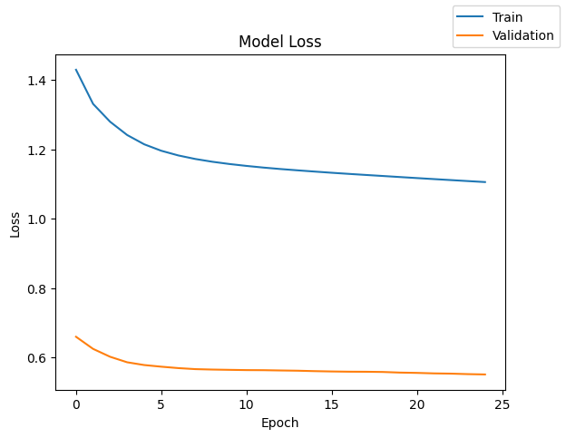

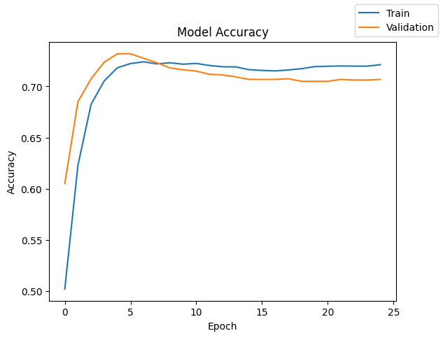

```python
from tensorflow.keras.optimizers import SGD
from tensorflow.keras.callbacks import EarlyStopping
# Clear previous models
tf.keras.backend.clear_session()

# Build model
model = Sequential([
    Dense(14, activation='relu', input_dim=X_train.shape[1]),
    Dense(7, activation='relu'),
    Dense(1, activation='sigmoid')
])

# Compile model with SGD
optimizer = SGD()
model.compile(loss='binary_crossentropy', optimizer=optimizer, metrics=['accuracy'])

# Early stopping to prevent overfitting
early_stop = EarlyStopping(monitor='val_loss', patience=10, restore_best_weights=True)

# Train model
history = model.fit(
    X_train, y_train,
    validation_data=(X_val, y_val),
    batch_size=64,
    epochs=25,
    class_weight=cw_dict,
    callbacks=[early_stop],
    verbose=1
)

# Plot training/validation loss
plot(history, 'loss')
plot(history, 'accuracy')

# Evaluate model
model_0_train_perf = model_performance_classification(model, X_train, y_train)
model_0_val_perf = model_performance_classification(model, X_val, y_val)

print("Train Performance:")
print(model_0_train_perf)
print("\nValidation Performance:")
print(model_0_val_perf)
```

```python
model.summary()
```

```
Model: "sequential"
```

```
┏━━━━━━━━━━━━━━━━━━━━━━━━━━━━━━━━━┳━━━━━━━━━━━━━━━━━━━━━━━━┳━━━━━━━━━━━━━━━┓
┃ Layer (type)                    ┃ Output Shape           ┃       Param # ┃
┡━━━━━━━━━━━━━━━━━━━━━━━━━━━━━━━━━╇━━━━━━━━━━━━━━━━━━━━━━━━╇━━━━━━━━━━━━━━━┩
│ dense (Dense)                   │ (None, 14)             │           168 │
├─────────────────────────────────┼────────────────────────┼───────────────┤
│ dense_1 (Dense)                 │ (None, 7)              │           105 │
├─────────────────────────────────┼────────────────────────┼───────────────┤
│ dense_2 (Dense)                 │ (None, 1)              │             8 │
└─────────────────────────────────┴────────────────────────┴───────────────┘
```

```
 Total params: 283 (1.11 KB)
```

```
 Trainable params: 281 (1.10 KB)
```

```
 Non-trainable params: 0 (0.00 B)
```

```
 Optimizer params: 2 (12.00 B)
```

## Model Performance Improvement

```
100/100 ━━━━━━━━━━━━━━━━━━━━ 3s 7ms/step - accuracy: 0.3507 - loss: 1.4725 - val_accuracy: 0.6650 - val_loss: 0.6289
100/100 ━━━━━━━━━━━━━━━━━━━━ 0s 4ms/step - accuracy: 0.6726 - loss: 1.2862 - val_accuracy: 0.7088 - val_loss: 0.5819
100/100 ━━━━━━━━━━━━━━━━━━━━ 1s 4ms/step - accuracy: 0.6989 - loss: 1.2195 - val_accuracy: 0.7262 - val_loss: 0.5588
100/100 ━━━━━━━━━━━━━━━━━━━━ 1s 4ms/step - accuracy: 0.7080 - loss: 1.1847 - val_accuracy: 0.7319 - val_loss: 0.5480
100/100 ━━━━━━━━━━━━━━━━━━━━ 1s 4ms/step - accuracy: 0.7079 - loss: 1.1647 - val_accuracy: 0.7325 - val_loss: 0.5424
100/100 ━━━━━━━━━━━━━━━━━━━━ 0s 4ms/step - accuracy: 0.7117 - loss: 1.1504 - val_accuracy: 0.7350 - val_loss: 0.5386
100/100 ━━━━━━━━━━━━━━━━━━━━ 0s 4ms/step - accuracy: 0.7147 - loss: 1.1405 - val_accuracy: 0.7350 - val_loss: 0.5346
100/100 ━━━━━━━━━━━━━━━━━━━━ 1s 3ms/step - accuracy: 0.7162 - loss: 1.1316 - val_accuracy: 0.7344 - val_loss: 0.5316
100/100 ━━━━━━━━━━━━━━━━━━━━ 1s 4ms/step - accuracy: 0.7185 - loss: 1.1227 - val_accuracy: 0.7362 - val_loss: 0.5292
100/100 ━━━━━━━━━━━━━━━━━━━━ 1s 4ms/step - accuracy: 0.7193 - loss: 1.1145 - val_accuracy: 0.7444 - val_loss: 0.5270
100/100 ━━━━━━━━━━━━━━━━━━━━ 1s 3ms/step - accuracy: 0.7220 - loss: 1.1067 - val_accuracy: 0.7469 - val_loss: 0.5241
100/100 ━━━━━━━━━━━━━━━━━━━━ 1s 4ms/step - accuracy: 0.7273 - loss: 1.0984 - val_accuracy: 0.7500 - val_loss: 0.5204
100/100 ━━━━━━━━━━━━━━━━━━━━ 0s 3ms/step - accuracy: 0.7329 - loss: 1.0896 - val_accuracy: 0.7544 - val_loss: 0.5169
100/100 ━━━━━━━━━━━━━━━━━━━━ 0s 3ms/step - accuracy: 0.7372 - loss: 1.0809 - val_accuracy: 0.7556 - val_loss: 0.5144
100/100 ━━━━━━━━━━━━━━━━━━━━ 1s 3ms/step - accuracy: 0.7439 - loss: 1.0727 - val_accuracy: 0.7613 - val_loss: 0.5120
100/100 ━━━━━━━━━━━━━━━━━━━━ 1s 4ms/step - accuracy: 0.7471 - loss: 1.0638 - val_accuracy: 0.7663 - val_loss: 0.5080
100/100 ━━━━━━━━━━━━━━━━━━━━ 0s 3ms/step - accuracy: 0.7529 - loss: 1.0557 - val_accuracy: 0.7694 - val_loss: 0.5041
100/100 ━━━━━━━━━━━━━━━━━━━━ 0s 3ms/step - accuracy: 0.7560 - loss: 1.0484 - val_accuracy: 0.7694 - val_loss: 0.5011
100/100 ━━━━━━━━━━━━━━━━━━━━ 1s 3ms/step - accuracy: 0.7597 - loss: 1.0414 - val_accuracy: 0.7694 - val_loss: 0.4980
100/100 ━━━━━━━━━━━━━━━━━━━━ 1s 6ms/step - accuracy: 0.7623 - loss: 1.0343 - val_accuracy: 0.7681 - val_loss: 0.4937
100/100 ━━━━━━━━━━━━━━━━━━━━ 1s 6ms/step - accuracy: 0.7652 - loss: 1.0281 - val_accuracy: 0.7688 - val_loss: 0.4898
100/100 ━━━━━━━━━━━━━━━━━━━━ 1s 4ms/step - accuracy: 0.7661 - loss: 1.0221 - val_accuracy: 0.7681 - val_loss: 0.4870
100/100 ━━━━━━━━━━━━━━━━━━━━ 0s 4ms/step - accuracy: 0.7693 - loss: 1.0166 - val_accuracy: 0.7669 - val_loss: 0.4838
100/100 ━━━━━━━━━━━━━━━━━━━━ 0s 3ms/step - accuracy: 0.7717 - loss: 1.0112 - val_accuracy: 0.7663 - val_loss: 0.4817
100/100 ━━━━━━━━━━━━━━━━━━━━ 0s 3ms/step - accuracy: 0.7709 - loss: 1.0061 - val_accuracy: 0.7694 - val_loss: 0.4794
200/200 ━━━━━━━━━━━━━━━━━━━━ 0s 1ms/step
50/50 ━━━━━━━━━━━━━━━━━━━━ 0s 2ms/step
Train Performance:
   Accuracy    Recall  Precision  F1 Score
0  0.787969  0.787969   0.831822  0.801855

Validation Performance:
   Accuracy    Recall  Precision  F1 Score
0  0.769375  0.769375   0.818472  0.785156
```

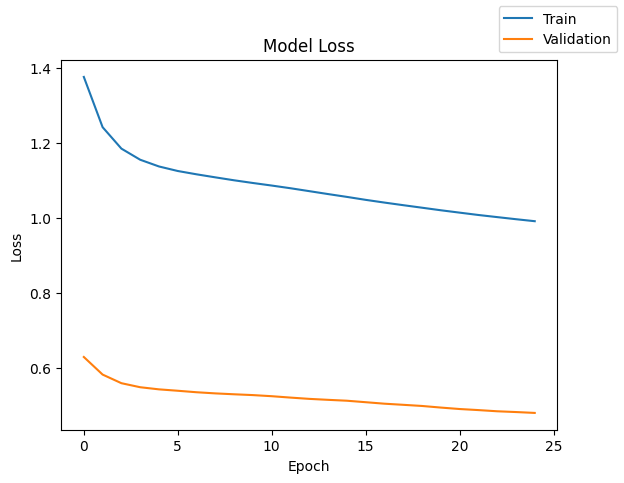

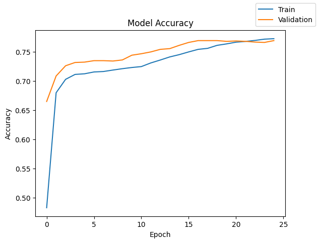

```python
from tensorflow.keras.models import Sequential
from tensorflow.keras.layers import Dense
from tensorflow.keras.optimizers import Adam
from tensorflow.keras.callbacks import EarlyStopping

# Clear backend session
tf.keras.backend.clear_session()

# Define the model
model = Sequential([
    Dense(14, activation='relu', input_dim=X_train.shape[1]),
    Dense(7, activation='relu'),
    Dense(1, activation='sigmoid')
])

# Compile with Adam optimizer
optimizer = Adam(learning_rate=0.001)  # Default is fine, but made explicit
model.compile(optimizer=optimizer, loss='binary_crossentropy', metrics=['accuracy'])

# Add early stopping
early_stop = EarlyStopping(monitor='val_loss', patience=10, restore_best_weights=True)

# Train the model
history = model.fit(
    X_train, y_train,
    validation_data=(X_val, y_val),
    batch_size=64,
    epochs=25,
    class_weight=cw_dict,
    callbacks=[early_stop],
    verbose=1
)

# Plot training/validation loss and accuracy
plot(history, 'loss')
plot(history, 'accuracy')

# Evaluate the model
model_2_train_perf = model_performance_classification(model, X_train, y_train)
model_2_valid_perf = model_performance_classification(model, X_val, y_val)

print("Train Performance:")
print(model_2_train_perf)
print("\nValidation Performance:")
print(model_2_valid_perf)
```

Model 4 (Neural Network with Adam Optimizer and Dropout)

```
100/100 ━━━━━━━━━━━━━━━━━━━━ 3s 7ms/step - accuracy: 0.6635 - loss: 1.3366 - val_accuracy: 0.6894 - val_loss: 0.5781
100/100 ━━━━━━━━━━━━━━━━━━━━ 0s 4ms/step - accuracy: 0.6871 - loss: 1.1819 - val_accuracy: 0.7100 - val_loss: 0.5485
100/100 ━━━━━━━━━━━━━━━━━━━━ 1s 5ms/step - accuracy: 0.6963 - loss: 1.1572 - val_accuracy: 0.7044 - val_loss: 0.5571
100/100 ━━━━━━━━━━━━━━━━━━━━ 1s 4ms/step - accuracy: 0.7054 - loss: 1.1249 - val_accuracy: 0.7231 - val_loss: 0.5356
100/100 ━━━━━━━━━━━━━━━━━━━━ 1s 4ms/step - accuracy: 0.7262 - loss: 1.0826 - val_accuracy: 0.7394 - val_loss: 0.5126
100/100 ━━━━━━━━━━━━━━━━━━━━ 1s 4ms/step - accuracy: 0.7355 - loss: 1.0441 - val_accuracy: 0.7506 - val_loss: 0.4957
100/100 ━━━━━━━━━━━━━━━━━━━━ 0s 4ms/step - accuracy: 0.7399 - loss: 1.0387 - val_accuracy: 0.7544 - val_loss: 0.4915
100/100 ━━━━━━━━━━━━━━━━━━━━ 0s 4ms/step - accuracy: 0.7411 - loss: 1.0356 - val_accuracy: 0.7437 - val_loss: 0.5022
100/100 ━━━━━━━━━━━━━━━━━━━━ 1s 7ms/step - accuracy: 0.7543 - loss: 0.9966 - val_accuracy: 0.7681 - val_loss: 0.4770
100/100 ━━━━━━━━━━━━━━━━━━━━ 1s 7ms/step - accuracy: 0.7676 - loss: 0.9886 - val_accuracy: 0.7638 - val_loss: 0.4868
100/100 ━━━━━━━━━━━━━━━━━━━━ 1s 4ms/step - accuracy: 0.7610 - loss: 0.9928 - val_accuracy: 0.7719 - val_loss: 0.4811
100/100 ━━━━━━━━━━━━━━━━━━━━ 1s 4ms/step - accuracy: 0.7702 - loss: 0.9593 - val_accuracy: 0.7825 - val_loss: 0.4627
100/100 ━━━━━━━━━━━━━━━━━━━━ 1s 4ms/step - accuracy: 0.7733 - loss: 0.9689 - val_accuracy: 0.7881 - val_loss: 0.4565
100/100 ━━━━━━━━━━━━━━━━━━━━ 1s 5ms/step - accuracy: 0.7794 - loss: 0.9424 - val_accuracy: 0.7800 - val_loss: 0.4641
100/100 ━━━━━━━━━━━━━━━━━━━━ 1s 4ms/step - accuracy: 0.7838 - loss: 0.9381 - val_accuracy: 0.7869 - val_loss: 0.4559
100/100 ━━━━━━━━━━━━━━━━━━━━ 1s 5ms/step - accuracy: 0.7783 - loss: 0.9218 - val_accuracy: 0.7788 - val_loss: 0.4692
100/100 ━━━━━━━━━━━━━━━━━━━━ 1s 4ms/step - accuracy: 0.7817 - loss: 0.9162 - val_accuracy: 0.7919 - val_loss: 0.4539
100/100 ━━━━━━━━━━━━━━━━━━━━ 1s 4ms/step - accuracy: 0.7922 - loss: 0.9098 - val_accuracy: 0.7912 - val_loss: 0.4475
100/100 ━━━━━━━━━━━━━━━━━━━━ 1s 4ms/step - accuracy: 0.7903 - loss: 0.9070 - val_accuracy: 0.7937 - val_loss: 0.4373
100/100 ━━━━━━━━━━━━━━━━━━━━ 1s 5ms/step - accuracy: 0.7855 - loss: 0.9175 - val_accuracy: 0.8025 - val_loss: 0.4411
100/100 ━━━━━━━━━━━━━━━━━━━━ 1s 4ms/step - accuracy: 0.7910 - loss: 0.9003 - val_accuracy: 0.8012 - val_loss: 0.4457
100/100 ━━━━━━━━━━━━━━━━━━━━ 1s 5ms/step - accuracy: 0.7826 - loss: 0.9070 - val_accuracy: 0.7956 - val_loss: 0.4478
100/100 ━━━━━━━━━━━━━━━━━━━━ 1s 5ms/step - accuracy: 0.7890 - loss: 0.8771 - val_accuracy: 0.7950 - val_loss: 0.4525
100/100 ━━━━━━━━━━━━━━━━━━━━ 1s 5ms/step - accuracy: 0.7940 - loss: 0.8853 - val_accuracy: 0.7975 - val_loss: 0.4450
100/100 ━━━━━━━━━━━━━━━━━━━━ 1s 5ms/step - accuracy: 0.7907 - loss: 0.8885 - val_accuracy: 0.7950 - val_loss: 0.4490
100/100 ━━━━━━━━━━━━━━━━━━━━ 1s 5ms/step - accuracy: 0.7887 - loss: 0.8819 - val_accuracy: 0.7975 - val_loss: 0.4427
100/100 ━━━━━━━━━━━━━━━━━━━━ 1s 7ms/step - accuracy: 0.7922 - loss: 0.8737 - val_accuracy: 0.8012 - val_loss: 0.4373
100/100 ━━━━━━━━━━━━━━━━━━━━ 1s 7ms/step - accuracy: 0.7870 - loss: 0.8631 - val_accuracy: 0.8025 - val_loss: 0.4412
100/100 ━━━━━━━━━━━━━━━━━━━━ 1s 6ms/step - accuracy: 0.7916 - loss: 0.8626 - val_accuracy: 0.8031 - val_loss: 0.4300
100/100 ━━━━━━━━━━━━━━━━━━━━ 0s 4ms/step - accuracy: 0.7879 - loss: 0.8628 - val_accuracy: 0.8000 - val_loss: 0.4416
100/100 ━━━━━━━━━━━━━━━━━━━━ 1s 5ms/step - accuracy: 0.7937 - loss: 0.8543 - val_accuracy: 0.7975 - val_loss: 0.4384
100/100 ━━━━━━━━━━━━━━━━━━━━ 0s 5ms/step - accuracy: 0.7968 - loss: 0.8541 - val_accuracy: 0.8050 - val_loss: 0.4266
100/100 ━━━━━━━━━━━━━━━━━━━━ 0s 5ms/step - accuracy: 0.7976 - loss: 0.8346 - val_accuracy: 0.7956 - val_loss: 0.4473
100/100 ━━━━━━━━━━━━━━━━━━━━ 0s 4ms/step - accuracy: 0.7951 - loss: 0.8553 - val_accuracy: 0.7987 - val_loss: 0.4414
100/100 ━━━━━━━━━━━━━━━━━━━━ 1s 4ms/step - accuracy: 0.8033 - loss: 0.8278 - val_accuracy: 0.7937 - val_loss: 0.4417
100/100 ━━━━━━━━━━━━━━━━━━━━ 1s 5ms/step - accuracy: 0.7911 - loss: 0.8423 - val_accuracy: 0.7962 - val_loss: 0.4412
100/100 ━━━━━━━━━━━━━━━━━━━━ 0s 4ms/step - accuracy: 0.8034 - loss: 0.8322 - val_accuracy: 0.7987 - val_loss: 0.4393
100/100 ━━━━━━━━━━━━━━━━━━━━ 1s 4ms/step - accuracy: 0.8041 - loss: 0.8246 - val_accuracy: 0.7912 - val_loss: 0.4436
100/100 ━━━━━━━━━━━━━━━━━━━━ 1s 4ms/step - accuracy: 0.7957 - loss: 0.8312 - val_accuracy: 0.8006 - val_loss: 0.4351
```

[output cut: 20 more lines]

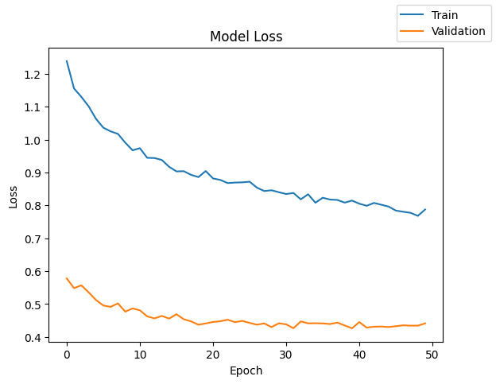

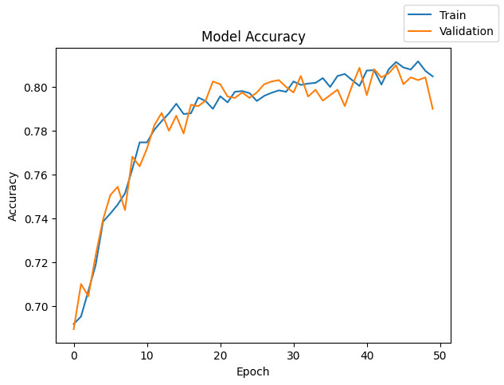

```python
from tensorflow.keras.models import Sequential
from tensorflow.keras.layers import Dense, Dropout
from tensorflow.keras.optimizers import Adam
from tensorflow.keras.callbacks import EarlyStopping

# Clear any previous model from memory
tf.keras.backend.clear_session()

# Define the model with dropout
model = Sequential([
    Dense(128, activation='relu', input_dim=X_train.shape[1]),
    Dropout(0.2),
    Dense(64, activation='relu'),
    Dropout(0.2),
    Dense(32, activation='relu'),
    Dense(1, activation='sigmoid')
])

# Compile with Adam optimizer
optimizer = Adam(learning_rate=0.001)
model.compile(loss='binary_crossentropy', optimizer=optimizer, metrics=['accuracy'])

# Early stopping to avoid overfitting
early_stop = EarlyStopping(monitor='val_loss', patience=10, restore_best_weights=True)

# Train the model
history = model.fit(
    X_train, y_train,
    batch_size=64,
    epochs=100,
    validation_data=(X_val, y_val),
    class_weight=cw_dict,  # Important if SMOTE is not used
    callbacks=[early_stop],
    verbose=1
)

# Plot learning curves
plot(history, 'loss')
plot(history, 'accuracy')

# Evaluate
model_4_train_perf = model_performance_classification(model, X_train, y_train)
model_4_valid_perf = model_performance_classification(model, X_val, y_val)

print("Train Performance:")
print(model_4_train_perf)
print("\nValidation Performance:")
print(model_4_valid_perf)
```

### Neural Network with Balanced Data (by applying SMOTE) and SGD Optimizer

```
319/319 ━━━━━━━━━━━━━━━━━━━━ 2s 4ms/step - accuracy: 0.5895 - loss: 0.6695 - val_accuracy: 0.5744 - val_loss: 0.7277
319/319 ━━━━━━━━━━━━━━━━━━━━ 2s 7ms/step - accuracy: 0.6737 - loss: 0.6019 - val_accuracy: 0.5669 - val_loss: 0.7648
319/319 ━━━━━━━━━━━━━━━━━━━━ 3s 8ms/step - accuracy: 0.7144 - loss: 0.5600 - val_accuracy: 0.6450 - val_loss: 0.6569
319/319 ━━━━━━━━━━━━━━━━━━━━ 4s 3ms/step - accuracy: 0.7130 - loss: 0.5546 - val_accuracy: 0.6575 - val_loss: 0.6466
319/319 ━━━━━━━━━━━━━━━━━━━━ 1s 3ms/step - accuracy: 0.7314 - loss: 0.5394 - val_accuracy: 0.6587 - val_loss: 0.6272
319/319 ━━━━━━━━━━━━━━━━━━━━ 1s 3ms/step - accuracy: 0.7301 - loss: 0.5349 - val_accuracy: 0.6744 - val_loss: 0.6286
319/319 ━━━━━━━━━━━━━━━━━━━━ 1s 3ms/step - accuracy: 0.7373 - loss: 0.5320 - val_accuracy: 0.6812 - val_loss: 0.6149
319/319 ━━━━━━━━━━━━━━━━━━━━ 1s 3ms/step - accuracy: 0.7350 - loss: 0.5298 - val_accuracy: 0.6681 - val_loss: 0.6529
319/319 ━━━━━━━━━━━━━━━━━━━━ 1s 3ms/step - accuracy: 0.7393 - loss: 0.5264 - val_accuracy: 0.6681 - val_loss: 0.6406
319/319 ━━━━━━━━━━━━━━━━━━━━ 1s 4ms/step - accuracy: 0.7410 - loss: 0.5244 - val_accuracy: 0.6981 - val_loss: 0.5907
319/319 ━━━━━━━━━━━━━━━━━━━━ 2s 3ms/step - accuracy: 0.7374 - loss: 0.5231 - val_accuracy: 0.6769 - val_loss: 0.6265
319/319 ━━━━━━━━━━━━━━━━━━━━ 1s 3ms/step - accuracy: 0.7428 - loss: 0.5200 - val_accuracy: 0.6769 - val_loss: 0.6266
319/319 ━━━━━━━━━━━━━━━━━━━━ 1s 3ms/step - accuracy: 0.7457 - loss: 0.5190 - val_accuracy: 0.6819 - val_loss: 0.6103
319/319 ━━━━━━━━━━━━━━━━━━━━ 1s 3ms/step - accuracy: 0.7444 - loss: 0.5202 - val_accuracy: 0.6862 - val_loss: 0.6091
319/319 ━━━━━━━━━━━━━━━━━━━━ 1s 3ms/step - accuracy: 0.7471 - loss: 0.5158 - val_accuracy: 0.6925 - val_loss: 0.5989
319/319 ━━━━━━━━━━━━━━━━━━━━ 1s 3ms/step - accuracy: 0.7440 - loss: 0.5148 - val_accuracy: 0.6888 - val_loss: 0.5894
319/319 ━━━━━━━━━━━━━━━━━━━━ 1s 3ms/step - accuracy: 0.7498 - loss: 0.5122 - val_accuracy: 0.6938 - val_loss: 0.5877
319/319 ━━━━━━━━━━━━━━━━━━━━ 1s 3ms/step - accuracy: 0.7467 - loss: 0.5129 - val_accuracy: 0.6781 - val_loss: 0.6171
319/319 ━━━━━━━━━━━━━━━━━━━━ 2s 5ms/step - accuracy: 0.7492 - loss: 0.5100 - val_accuracy: 0.6869 - val_loss: 0.5977
319/319 ━━━━━━━━━━━━━━━━━━━━ 1s 4ms/step - accuracy: 0.7469 - loss: 0.5106 - val_accuracy: 0.7000 - val_loss: 0.5813
319/319 ━━━━━━━━━━━━━━━━━━━━ 2s 4ms/step - accuracy: 0.7488 - loss: 0.5093 - val_accuracy: 0.7200 - val_loss: 0.5435
319/319 ━━━━━━━━━━━━━━━━━━━━ 1s 3ms/step - accuracy: 0.7488 - loss: 0.5106 - val_accuracy: 0.6800 - val_loss: 0.6148
319/319 ━━━━━━━━━━━━━━━━━━━━ 1s 3ms/step - accuracy: 0.7497 - loss: 0.5076 - val_accuracy: 0.7138 - val_loss: 0.5513
319/319 ━━━━━━━━━━━━━━━━━━━━ 1s 3ms/step - accuracy: 0.7502 - loss: 0.5077 - val_accuracy: 0.7138 - val_loss: 0.5524
319/319 ━━━━━━━━━━━━━━━━━━━━ 1s 3ms/step - accuracy: 0.7492 - loss: 0.5077 - val_accuracy: 0.6869 - val_loss: 0.5989
319/319 ━━━━━━━━━━━━━━━━━━━━ 1s 3ms/step - accuracy: 0.7496 - loss: 0.5037 - val_accuracy: 0.7156 - val_loss: 0.5518
319/319 ━━━━━━━━━━━━━━━━━━━━ 1s 3ms/step - accuracy: 0.7492 - loss: 0.5053 - val_accuracy: 0.7169 - val_loss: 0.5358
319/319 ━━━━━━━━━━━━━━━━━━━━ 1s 3ms/step - accuracy: 0.7523 - loss: 0.5061 - val_accuracy: 0.6994 - val_loss: 0.5742
319/319 ━━━━━━━━━━━━━━━━━━━━ 2s 5ms/step - accuracy: 0.7533 - loss: 0.5007 - val_accuracy: 0.7188 - val_loss: 0.5470
319/319 ━━━━━━━━━━━━━━━━━━━━ 2s 5ms/step - accuracy: 0.7532 - loss: 0.5020 - val_accuracy: 0.7069 - val_loss: 0.5640
319/319 ━━━━━━━━━━━━━━━━━━━━ 1s 3ms/step - accuracy: 0.7539 - loss: 0.5005 - val_accuracy: 0.7362 - val_loss: 0.5141
319/319 ━━━━━━━━━━━━━━━━━━━━ 1s 3ms/step - accuracy: 0.7490 - loss: 0.5042 - val_accuracy: 0.7375 - val_loss: 0.5170
319/319 ━━━━━━━━━━━━━━━━━━━━ 1s 3ms/step - accuracy: 0.7545 - loss: 0.5006 - val_accuracy: 0.7487 - val_loss: 0.5003
319/319 ━━━━━━━━━━━━━━━━━━━━ 1s 3ms/step - accuracy: 0.7498 - loss: 0.5028 - val_accuracy: 0.7375 - val_loss: 0.5196
319/319 ━━━━━━━━━━━━━━━━━━━━ 1s 3ms/step - accuracy: 0.7532 - loss: 0.4989 - val_accuracy: 0.7500 - val_loss: 0.5052
319/319 ━━━━━━━━━━━━━━━━━━━━ 1s 3ms/step - accuracy: 0.7513 - loss: 0.4994 - val_accuracy: 0.7656 - val_loss: 0.4833
319/319 ━━━━━━━━━━━━━━━━━━━━ 1s 3ms/step - accuracy: 0.7511 - loss: 0.4962 - val_accuracy: 0.7525 - val_loss: 0.5075
319/319 ━━━━━━━━━━━━━━━━━━━━ 1s 3ms/step - accuracy: 0.7537 - loss: 0.4938 - val_accuracy: 0.7306 - val_loss: 0.5327
319/319 ━━━━━━━━━━━━━━━━━━━━ 2s 5ms/step - accuracy: 0.7551 - loss: 0.4950 - val_accuracy: 0.7606 - val_loss: 0.4903
319/319 ━━━━━━━━━━━━━━━━━━━━ 2s 5ms/step - accuracy: 0.7548 - loss: 0.4964 - val_accuracy: 0.7444 - val_loss: 0.5078
319/319 ━━━━━━━━━━━━━━━━━━━━ 1s 4ms/step - accuracy: 0.7598 - loss: 0.4895 - val_accuracy: 0.7025 - val_loss: 0.5707
319/319 ━━━━━━━━━━━━━━━━━━━━ 1s 4ms/step - accuracy: 0.7618 - loss: 0.4885 - val_accuracy: 0.7519 - val_loss: 0.5042
319/319 ━━━━━━━━━━━━━━━━━━━━ 1s 3ms/step - accuracy: 0.7620 - loss: 0.4888 - val_accuracy: 0.7275 - val_loss: 0.5316
319/319 ━━━━━━━━━━━━━━━━━━━━ 1s 3ms/step - accuracy: 0.7586 - loss: 0.4897 - val_accuracy: 0.7275 - val_loss: 0.5282
319/319 ━━━━━━━━━━━━━━━━━━━━ 1s 4ms/step - accuracy: 0.7617 - loss: 0.4883 - val_accuracy: 0.7450 - val_loss: 0.5157
319/319 ━━━━━━━━━━━━━━━━━━━━ 1s 3ms/step - accuracy: 0.7628 - loss: 0.4871 - val_accuracy: 0.7237 - val_loss: 0.5316
200/200 ━━━━━━━━━━━━━━━━━━━━ 0s 1ms/step
50/50 ━━━━━━━━━━━━━━━━━━━━ 0s 2ms/step
Train Performance:
    Accuracy    Recall  Precision  F1 Score
0  0.774219  0.774219   0.826103  0.790238

Validation Performance:
    Accuracy    Recall  Precision  F1 Score
0  0.765625  0.765625   0.812569  0.781178
```

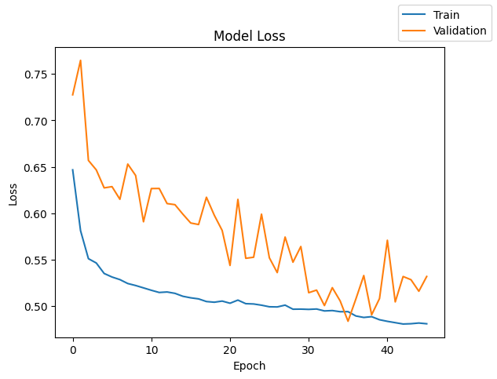

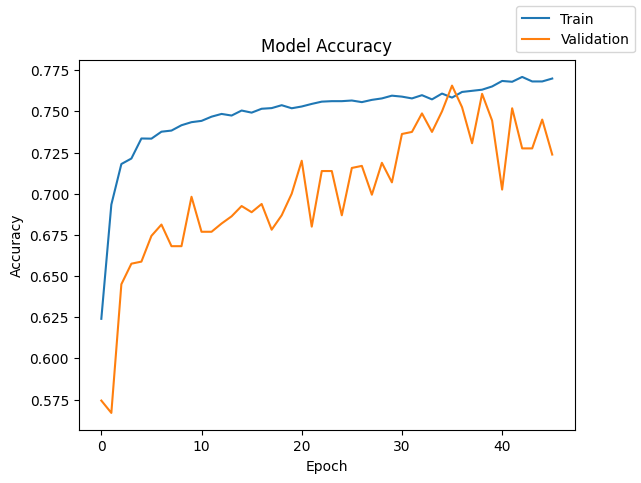

```python
from imblearn.over_sampling import SMOTE
from sklearn.preprocessing import StandardScaler
from tensorflow.keras.models import Sequential
from tensorflow.keras.layers import Dense
from tensorflow.keras.optimizers import SGD
from tensorflow.keras.callbacks import EarlyStopping

# Clear session
tf.keras.backend.clear_session()

# Apply SMOTE
smote = SMOTE(random_state=42)
X_train_bal, y_train_bal = smote.fit_resample(X_train, y_train)

# Use the original scaler fit on X_train
X_train_bal[num_cols] = scaler.transform(X_train_bal[num_cols])
X_val_scaled = X_val.copy()
X_val_scaled[num_cols] = scaler.transform(X_val_scaled[num_cols])
X_train_scaled = X_train.copy()
X_train_scaled[num_cols] = scaler.transform(X_train_scaled[num_cols])

# Build the model
model = Sequential([
    Dense(32, activation='relu', input_shape=(X_train_bal.shape[1],)),
    Dense(16, activation='relu'),
    Dense(1, activation='sigmoid')
])

# Compile with SGD
sgd = SGD(learning_rate=0.01, momentum=0.9)
model.compile(optimizer=sgd, loss='binary_crossentropy', metrics=['accuracy'])

# Train the model with EarlyStopping
early_stop = EarlyStopping(monitor='val_loss', patience=10, restore_best_weights=True)
history = model.fit(
    X_train_bal, y_train_bal,
    validation_data=(X_val_scaled, y_val),
    epochs=50,
    batch_size=32,
    verbose=1,
    callbacks=[early_stop]
)

# Plot loss and accuracy
plot(history, 'loss')
plot(history, 'accuracy')

# Evaluate model on scaled original data
model_5_train_perf = model_performance_classification(model, X_train_scaled, y_train)
model_5_valid_perf = model_performance_classification(model, X_val_scaled, y_val)

print("Train Performance:\n", model_5_train_perf)
print("\nValidation Performance:\n", model_5_valid_perf)
```

### Neural Network with Balanced Data (by applying SMOTE) and Adam Optimizer

```
319/319 ━━━━━━━━━━━━━━━━━━━━ 4s 4ms/step - accuracy: 0.5987 - loss: 0.8830 - val_accuracy: 0.6681 - val_loss: 0.6340
319/319 ━━━━━━━━━━━━━━━━━━━━ 1s 4ms/step - accuracy: 0.7085 - loss: 0.5795 - val_accuracy: 0.7050 - val_loss: 0.5847
319/319 ━━━━━━━━━━━━━━━━━━━━ 1s 3ms/step - accuracy: 0.7212 - loss: 0.5452 - val_accuracy: 0.7019 - val_loss: 0.5746
319/319 ━━━━━━━━━━━━━━━━━━━━ 1s 3ms/step - accuracy: 0.7232 - loss: 0.5375 - val_accuracy: 0.7094 - val_loss: 0.5591
319/319 ━━━━━━━━━━━━━━━━━━━━ 1s 3ms/step - accuracy: 0.7253 - loss: 0.5334 - val_accuracy: 0.7113 - val_loss: 0.5580
319/319 ━━━━━━━━━━━━━━━━━━━━ 1s 4ms/step - accuracy: 0.7275 - loss: 0.5311 - val_accuracy: 0.7138 - val_loss: 0.5588
319/319 ━━━━━━━━━━━━━━━━━━━━ 2s 3ms/step - accuracy: 0.7289 - loss: 0.5294 - val_accuracy: 0.7169 - val_loss: 0.5557
319/319 ━━━━━━━━━━━━━━━━━━━━ 1s 3ms/step - accuracy: 0.7301 - loss: 0.5274 - val_accuracy: 0.7175 - val_loss: 0.5501
319/319 ━━━━━━━━━━━━━━━━━━━━ 1s 3ms/step - accuracy: 0.7304 - loss: 0.5256 - val_accuracy: 0.7125 - val_loss: 0.5551
319/319 ━━━━━━━━━━━━━━━━━━━━ 1s 3ms/step - accuracy: 0.7322 - loss: 0.5239 - val_accuracy: 0.7181 - val_loss: 0.5479
319/319 ━━━━━━━━━━━━━━━━━━━━ 1s 3ms/step - accuracy: 0.7353 - loss: 0.5217 - val_accuracy: 0.7181 - val_loss: 0.5490
319/319 ━━━━━━━━━━━━━━━━━━━━ 1s 3ms/step - accuracy: 0.7365 - loss: 0.5201 - val_accuracy: 0.7212 - val_loss: 0.5399
319/319 ━━━━━━━━━━━━━━━━━━━━ 1s 3ms/step - accuracy: 0.7398 - loss: 0.5173 - val_accuracy: 0.7219 - val_loss: 0.5372
319/319 ━━━━━━━━━━━━━━━━━━━━ 1s 4ms/step - accuracy: 0.7419 - loss: 0.5154 - val_accuracy: 0.7225 - val_loss: 0.5345
319/319 ━━━━━━━━━━━━━━━━━━━━ 3s 4ms/step - accuracy: 0.7435 - loss: 0.5134 - val_accuracy: 0.7269 - val_loss: 0.5320
319/319 ━━━━━━━━━━━━━━━━━━━━ 2s 3ms/step - accuracy: 0.7443 - loss: 0.5115 - val_accuracy: 0.7262 - val_loss: 0.5299
319/319 ━━━━━━━━━━━━━━━━━━━━ 1s 4ms/step - accuracy: 0.7480 - loss: 0.5096 - val_accuracy: 0.7287 - val_loss: 0.5298
319/319 ━━━━━━━━━━━━━━━━━━━━ 1s 3ms/step - accuracy: 0.7473 - loss: 0.5079 - val_accuracy: 0.7262 - val_loss: 0.5314
319/319 ━━━━━━━━━━━━━━━━━━━━ 1s 4ms/step - accuracy: 0.7501 - loss: 0.5062 - val_accuracy: 0.7275 - val_loss: 0.5329
319/319 ━━━━━━━━━━━━━━━━━━━━ 1s 3ms/step - accuracy: 0.7501 - loss: 0.5046 - val_accuracy: 0.7237 - val_loss: 0.5401
319/319 ━━━━━━━━━━━━━━━━━━━━ 1s 3ms/step - accuracy: 0.7510 - loss: 0.5031 - val_accuracy: 0.7194 - val_loss: 0.5466
319/319 ━━━━━━━━━━━━━━━━━━━━ 1s 3ms/step - accuracy: 0.7516 - loss: 0.5018 - val_accuracy: 0.7194 - val_loss: 0.5471
319/319 ━━━━━━━━━━━━━━━━━━━━ 1s 4ms/step - accuracy: 0.7520 - loss: 0.5000 - val_accuracy: 0.7144 - val_loss: 0.5520
319/319 ━━━━━━━━━━━━━━━━━━━━ 2s 3ms/step - accuracy: 0.7544 - loss: 0.4985 - val_accuracy: 0.7131 - val_loss: 0.5562
319/319 ━━━━━━━━━━━━━━━━━━━━ 1s 3ms/step - accuracy: 0.7562 - loss: 0.4977 - val_accuracy: 0.7100 - val_loss: 0.5606
319/319 ━━━━━━━━━━━━━━━━━━━━ 1s 3ms/step - accuracy: 0.7579 - loss: 0.4965 - val_accuracy: 0.7088 - val_loss: 0.5641
319/319 ━━━━━━━━━━━━━━━━━━━━ 1s 3ms/step - accuracy: 0.7568 - loss: 0.4957 - val_accuracy: 0.7150 - val_loss: 0.5580
200/200 ━━━━━━━━━━━━━━━━━━━━ 0s 1ms/step
50/50 ━━━━━━━━━━━━━━━━━━━━ 0s 2ms/step
Train Performance:
    Accuracy    Recall  Precision  F1 Score
0  0.735156  0.735156   0.813372  0.757463

Validation Performance:
    Accuracy   Recall  Precision  F1 Score
0   0.72875  0.72875   0.813908  0.752316
```

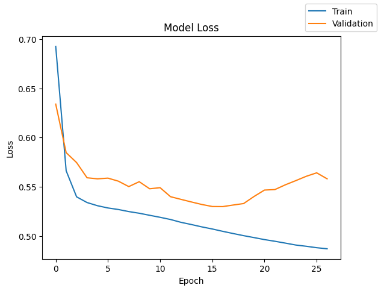

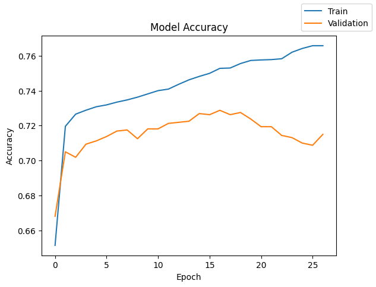

```python
from imblearn.over_sampling import SMOTE
from tensorflow.keras.models import Sequential
from tensorflow.keras.layers import Dense
from tensorflow.keras.optimizers import Adam
from tensorflow.keras.callbacks import EarlyStopping

# Clear previous models
tf.keras.backend.clear_session()

# Apply SMOTE
smote = SMOTE(random_state=42)
X_train_bal, y_train_bal = smote.fit_resample(X_train, y_train)

# Scale using original scaler
X_train_bal[num_cols] = scaler.transform(X_train_bal[num_cols])
X_val_scaled = X_val.copy()
X_val_scaled[num_cols] = scaler.transform(X_val_scaled[num_cols])
X_train_scaled = X_train.copy()
X_train_scaled[num_cols] = scaler.transform(X_train_scaled[num_cols])

# Define the model
model = Sequential([
    Dense(32, activation='relu', input_shape=(X_train_bal.shape[1],)),
    Dense(16, activation='relu'),
    Dense(1, activation='sigmoid')
])

# Compile with Adam optimizer
adam = Adam(learning_rate=0.001)
model.compile(optimizer=adam, loss='binary_crossentropy', metrics=['accuracy'])

# Train the model with EarlyStopping
early_stop = EarlyStopping(monitor='val_loss', patience=10, restore_best_weights=True)

history = model.fit(
    X_train_bal, y_train_bal,
    validation_data=(X_val_scaled, y_val),
    epochs=50,
    batch_size=32,
    callbacks=[early_stop],
    verbose=1
)

# Plot
plot(history, 'loss')
plot(history, 'accuracy')

# Evaluate
model_6_train_perf = model_performance_classification(model, X_train_scaled, y_train)
model_6_valid_perf = model_performance_classification(model, X_val_scaled, y_val)

print("Train Performance:\n", model_6_train_perf)
print("\nValidation Performance:\n", model_6_valid_perf)
```

### Neural Network with Balanced Data (by applying SMOTE), Adam Optimizer, and Dropout

```
319/319 ━━━━━━━━━━━━━━━━━━━━ 8s 10ms/step - accuracy: 0.5224 - loss: 0.7781 - val_accuracy: 0.5956 - val_loss: 0.6747
319/319 ━━━━━━━━━━━━━━━━━━━━ 4s 8ms/step - accuracy: 0.5807 - loss: 0.6698 - val_accuracy: 0.6137 - val_loss: 0.6510
319/319 ━━━━━━━━━━━━━━━━━━━━ 4s 4ms/step - accuracy: 0.6386 - loss: 0.6371 - val_accuracy: 0.6544 - val_loss: 0.6143
319/319 ━━━━━━━━━━━━━━━━━━━━ 1s 3ms/step - accuracy: 0.6892 - loss: 0.5979 - val_accuracy: 0.6669 - val_loss: 0.6083
319/319 ━━━━━━━━━━━━━━━━━━━━ 1s 3ms/step - accuracy: 0.7084 - loss: 0.5703 - val_accuracy: 0.7019 - val_loss: 0.5723
319/319 ━━━━━━━━━━━━━━━━━━━━ 1s 3ms/step - accuracy: 0.7172 - loss: 0.5620 - val_accuracy: 0.7094 - val_loss: 0.5475
319/319 ━━━━━━━━━━━━━━━━━━━━ 1s 3ms/step - accuracy: 0.7198 - loss: 0.5578 - val_accuracy: 0.7006 - val_loss: 0.5592
319/319 ━━━━━━━━━━━━━━━━━━━━ 1s 3ms/step - accuracy: 0.7202 - loss: 0.5591 - val_accuracy: 0.7063 - val_loss: 0.5487
319/319 ━━━━━━━━━━━━━━━━━━━━ 1s 4ms/step - accuracy: 0.7197 - loss: 0.5532 - val_accuracy: 0.7013 - val_loss: 0.5633
319/319 ━━━━━━━━━━━━━━━━━━━━ 1s 4ms/step - accuracy: 0.7262 - loss: 0.5538 - val_accuracy: 0.7063 - val_loss: 0.5481
319/319 ━━━━━━━━━━━━━━━━━━━━ 2s 5ms/step - accuracy: 0.7234 - loss: 0.5542 - val_accuracy: 0.6944 - val_loss: 0.5600
319/319 ━━━━━━━━━━━━━━━━━━━━ 2s 5ms/step - accuracy: 0.7267 - loss: 0.5495 - val_accuracy: 0.7050 - val_loss: 0.5504
319/319 ━━━━━━━━━━━━━━━━━━━━ 2s 4ms/step - accuracy: 0.7275 - loss: 0.5439 - val_accuracy: 0.7063 - val_loss: 0.5509
319/319 ━━━━━━━━━━━━━━━━━━━━ 1s 3ms/step - accuracy: 0.7307 - loss: 0.5402 - val_accuracy: 0.7050 - val_loss: 0.5574
319/319 ━━━━━━━━━━━━━━━━━━━━ 1s 3ms/step - accuracy: 0.7297 - loss: 0.5394 - val_accuracy: 0.7019 - val_loss: 0.5462
319/319 ━━━━━━━━━━━━━━━━━━━━ 1s 3ms/step - accuracy: 0.7288 - loss: 0.5386 - val_accuracy: 0.6969 - val_loss: 0.5556
319/319 ━━━━━━━━━━━━━━━━━━━━ 1s 3ms/step - accuracy: 0.7316 - loss: 0.5429 - val_accuracy: 0.7113 - val_loss: 0.5366
319/319 ━━━━━━━━━━━━━━━━━━━━ 1s 3ms/step - accuracy: 0.7297 - loss: 0.5371 - val_accuracy: 0.6988 - val_loss: 0.5529
319/319 ━━━━━━━━━━━━━━━━━━━━ 1s 4ms/step - accuracy: 0.7364 - loss: 0.5364 - val_accuracy: 0.7262 - val_loss: 0.5164
319/319 ━━━━━━━━━━━━━━━━━━━━ 2s 6ms/step - accuracy: 0.7340 - loss: 0.5334 - val_accuracy: 0.6963 - val_loss: 0.5629
319/319 ━━━━━━━━━━━━━━━━━━━━ 2s 4ms/step - accuracy: 0.7358 - loss: 0.5323 - val_accuracy: 0.7125 - val_loss: 0.5330
319/319 ━━━━━━━━━━━━━━━━━━━━ 1s 4ms/step - accuracy: 0.7352 - loss: 0.5272 - val_accuracy: 0.7219 - val_loss: 0.5271
319/319 ━━━━━━━━━━━━━━━━━━━━ 1s 3ms/step - accuracy: 0.7423 - loss: 0.5288 - val_accuracy: 0.7094 - val_loss: 0.5440
319/319 ━━━━━━━━━━━━━━━━━━━━ 1s 4ms/step - accuracy: 0.7396 - loss: 0.5296 - val_accuracy: 0.7031 - val_loss: 0.5494
319/319 ━━━━━━━━━━━━━━━━━━━━ 1s 4ms/step - accuracy: 0.7390 - loss: 0.5266 - val_accuracy: 0.7194 - val_loss: 0.5337
319/319 ━━━━━━━━━━━━━━━━━━━━ 1s 4ms/step - accuracy: 0.7427 - loss: 0.5264 - val_accuracy: 0.7019 - val_loss: 0.5566
319/319 ━━━━━━━━━━━━━━━━━━━━ 1s 4ms/step - accuracy: 0.7432 - loss: 0.5292 - val_accuracy: 0.7194 - val_loss: 0.5328
319/319 ━━━━━━━━━━━━━━━━━━━━ 1s 4ms/step - accuracy: 0.7427 - loss: 0.5198 - val_accuracy: 0.7219 - val_loss: 0.5331
319/319 ━━━━━━━━━━━━━━━━━━━━ 2s 6ms/step - accuracy: 0.7509 - loss: 0.5159 - val_accuracy: 0.7063 - val_loss: 0.5310
200/200 ━━━━━━━━━━━━━━━━━━━━ 0s 1ms/step
50/50 ━━━━━━━━━━━━━━━━━━━━ 0s 2ms/step
Train Performance:
    Accuracy    Recall  Precision  F1 Score
0  0.731875  0.731875   0.808733  0.754252

Validation Performance:
    Accuracy   Recall  Precision  F1 Score
0   0.72625  0.72625   0.805927  0.749383
```

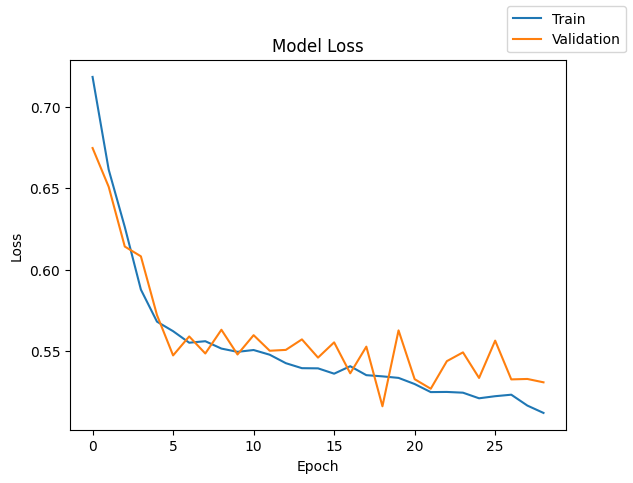

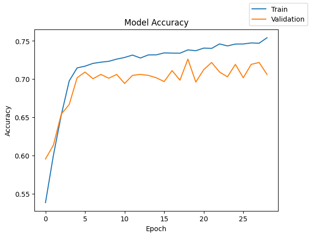

```python
from imblearn.over_sampling import SMOTE
from tensorflow.keras.models import Sequential
from tensorflow.keras.layers import Dense, Dropout
from tensorflow.keras.optimizers import Adam
from tensorflow.keras.callbacks import EarlyStopping

# Clear any previous model
tf.keras.backend.clear_session()

# Apply SMOTE
smote = SMOTE(random_state=42)
X_train_bal, y_train_bal = smote.fit_resample(X_train, y_train)

# Scale using previously fitted scaler
X_train_bal[num_cols] = scaler.transform(X_train_bal[num_cols])
X_val_scaled = X_val.copy()
X_val_scaled[num_cols] = scaler.transform(X_val_scaled[num_cols])
X_train_scaled = X_train.copy()
X_train_scaled[num_cols] = scaler.transform(X_train_scaled[num_cols])

# Define the model with dropout
model = Sequential([
    Dense(64, activation='relu', input_shape=(X_train_bal.shape[1],)),
    Dropout(0.3),
    Dense(32, activation='relu'),
    Dropout(0.3),
    Dense(1, activation='sigmoid')
])

# Compile
adam = Adam(learning_rate=0.001)
model.compile(optimizer=adam, loss='binary_crossentropy', metrics=['accuracy'])

# Early stopping
early_stop = EarlyStopping(monitor='val_loss', patience=10, restore_best_weights=True)

# Train
history = model.fit(
    X_train_bal, y_train_bal,
    validation_data=(X_val_scaled, y_val),
    epochs=50,
    batch_size=32,
    verbose=1,
    callbacks=[early_stop]
)

# Plot training metrics
plot(history, 'loss')
plot(history, 'accuracy')

# Evaluate on original data (scaled properly)
model_7_train_perf = model_performance_classification(model, X_train_scaled, y_train)
model_7_valid_perf = model_performance_classification(model, X_val_scaled, y_val)

print("Train Performance:\n", model_7_train_perf)
print("\nValidation Performance:\n", model_7_valid_perf)
```

## Model Performance Comparison and Final Model Selection

```python
import pandas as pd

# Combine validation performances
model_comparison = pd.concat([
    model_0_val_perf.assign(Model='Model 0 (SGD)'),
    model_2_valid_perf.assign(Model='Model 2 (Adam)'),
    model_4_valid_perf.assign(Model='Model 4 (Adam + Dropout)'),
    model_5_valid_perf.assign(Model='Model 5 (SMOTE + SGD)'),
    model_6_valid_perf.assign(Model='Model 6 (SMOTE + Adam)'),
    model_7_valid_perf.assign(Model='Model 7 (SMOTE + Adam + Dropout)')
], axis=0)

# Move 'Model' column to the front
cols = ['Model'] + [col for col in model_comparison.columns if col != 'Model']
model_comparison = model_comparison[cols]

# Display the comparison table
from IPython.display import display
display(model_comparison)
```

|  | Model | Accuracy | Recall | Precision | F1 Score |
| --- | --- | --- | --- | --- | --- |
| 0 | Model 0 (SGD) | 0.706875 | 0.706875 | 0.788738 | 0.731691 |
| 0 | Model 2 (Adam) | 0.769375 | 0.769375 | 0.818472 | 0.785156 |
| 0 | Model 4 (Adam + Dropout) | 0.808750 | 0.808750 | 0.840209 | 0.819262 |
| 0 | Model 5 (SMOTE + SGD) | 0.765625 | 0.765625 | 0.812569 | 0.781178 |
| 0 | Model 6 (SMOTE + Adam) | 0.728750 | 0.728750 | 0.813908 | 0.752316 |
| 0 | Model 7 (SMOTE + Adam + Dropout) | 0.726250 | 0.726250 | 0.805927 | 0.749383 |

Model 4 (Adam + Dropout) is clearly the best performer across all evaluation metrics on validation set.

## Actionable Insights and Business Recommendations

1. Launch a Churn Prevention Campaign

Use the model to score active customers weekly/monthly and:

Prioritize outreach to high-risk customers.

Offer tailored incentives such as lower fees, better interest rates, or personalized services to retain them.

2. Profile At-Risk Customers

Use the model’s predictions alongside customer features (e.g., age, balance, credit score) to understand which segments are most at risk: